# CMSC320 Final Tutorial

#### Leanne Brady

In this tutorial, I will be walking you through the data science pipeline.

To begin, we define the problem that we want to solve. In this tutorial we will be looking at national climate trends over the years.

## Data collection/curation

Now that we have defined a problem, the first step in the data science pipeline is data collection and preparation. Collecting data could involve exploring data databases, webscraping, or gathering data in other ways. For our example, I found data from the [National Oceanic and Atmospheric Administration](https://www.ncdc.noaa.gov/cag/national/time-series/110-tavg-all-12-1895-2020.csv?base_prd=true&begbaseyear=1901&endbaseyear=2000) with information on national tempuratures since 1895. This data is in the form of a csv file which means we can read it using the Pandas module:

```python
import pandas as pd
import numpy as np

data = pd.read_csv('/Users/leannebrady/Documents/CMSC320 Final Tutorial/GitHub.io/110-tavg-all-12-1895-2020.csv', skiprows=4)
data
```

|  | Date | Value | Anomaly |
| --- | --- | --- | --- |
| 0 | 189501 | 26.69 | -3.43 |
| 1 | 189502 | 26.60 | -7.22 |
| 2 | 189503 | 39.97 | -1.53 |
| 3 | 189504 | 52.90 | 1.85 |
| 4 | 189505 | 59.94 | -0.26 |
| ... | ... | ... | ... |
| 1507 | 202008 | 74.71 | 2.61 |
| 1508 | 202009 | 65.91 | 1.05 |
| 1509 | 202010 | 54.28 | 0.17 |
| 1510 | 202011 | 46.31 | 4.62 |
| 1511 | 202012 | 35.71 | 3.03 |

1512 rows × 3 columns

## Data management/representation

Now that we have the data, we need to tidy it. For example in the Date column the dates are stored as integers in a yyyymm format, and we would like to change those values into the DateTime data type in pandas so that later we can plot the temperature data across time.

```python
data['Date'] = pd.to_datetime(data['Date'], format="%Y%m")
data
```

|  | Date | Value | Anomaly |
| --- | --- | --- | --- |
| 0 | 1895-01-01 | 26.69 | -3.43 |
| 1 | 1895-02-01 | 26.60 | -7.22 |
| 2 | 1895-03-01 | 39.97 | -1.53 |
| 3 | 1895-04-01 | 52.90 | 1.85 |
| 4 | 1895-05-01 | 59.94 | -0.26 |
| ... | ... | ... | ... |
| 1507 | 2020-08-01 | 74.71 | 2.61 |
| 1508 | 2020-09-01 | 65.91 | 1.05 |
| 1509 | 2020-10-01 | 54.28 | 0.17 |
| 1510 | 2020-11-01 | 46.31 | 4.62 |
| 1511 | 2020-12-01 | 35.71 | 3.03 |

1512 rows × 3 columns

Next we should check for missing values in the data. We can do this by using the pandas isnull method:

```python
data[pd.isnull(data)].count()
```

```
Date       0
Value      0
Anomaly    0
dtype: int64
```

This dataset does not have any missing values so we can continue onto the next step.

## Exploratory Data Analysis

Next, we want to analyze and summarize the data we have in order to find trends or relationships. First lets graph the average temperatures across time:

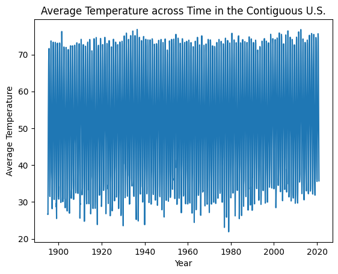

```python
import seaborn as sns
import matplotlib
import matplotlib.pyplot as plt

fig, ax = plt.subplots()
plt.title("Average Temperature across Time in the Contiguous U.S.")
plt.xlabel("Year")
plt.ylabel("Average Temperature")
fig = sns.lineplot(y=data['Value'], x=data['Date'])
plt.show()
```

This first attempt at plotting the data did not give clear insight into the temperature trends over time since we have temperature data of the entire year for over 100 years, when temperature varies depending on the time of the year. We should instead categorize the temperature data into seasons and plot each average seasonal temperature:

```python
import datetime

season = []
for row in data['Date'].dt.month:
    if row in range(3,6):
        season.append('spring')
    elif row in range(6,9):
        season.append('summer')
    elif row in range(9,12):
        season.append('fall')
    else:
        season.append('winter')

data['Season'] = season
data
```

|  | Date | Value | Anomaly | Season |
| --- | --- | --- | --- | --- |
| 0 | 1895-01-01 | 26.69 | -3.43 | winter |
| 1 | 1895-02-01 | 26.60 | -7.22 | winter |
| 2 | 1895-03-01 | 39.97 | -1.53 | spring |
| 3 | 1895-04-01 | 52.90 | 1.85 | spring |
| 4 | 1895-05-01 | 59.94 | -0.26 | spring |
| ... | ... | ... | ... | ... |
| 1507 | 2020-08-01 | 74.71 | 2.61 | summer |
| 1508 | 2020-09-01 | 65.91 | 1.05 | fall |
| 1509 | 2020-10-01 | 54.28 | 0.17 | fall |
| 1510 | 2020-11-01 | 46.31 | 4.62 | fall |
| 1511 | 2020-12-01 | 35.71 | 3.03 | winter |

1512 rows × 4 columns

Now with this added season column, we can plot the average temperature by season:

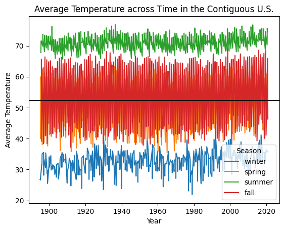

```python
fig = sns.lineplot(x=data['Date'], y=data['Value'], data=data, hue=data['Season'])
plt.title("Average Temperature across Time in the Contiguous U.S.")
plt.xlabel("Year")
plt.ylabel("Average Temperature")
plt.axhline(data['Value'].mean(), color='black')
plt.show()
```

```python
season_avg = data.groupby('Season')['Value'].mean()
season_avg
```

```
Season
fall      53.744286
spring    51.137011
summer    71.605741
winter    32.447646
Name: Value, dtype: float64
```

We'll also plot the average annual temperature:

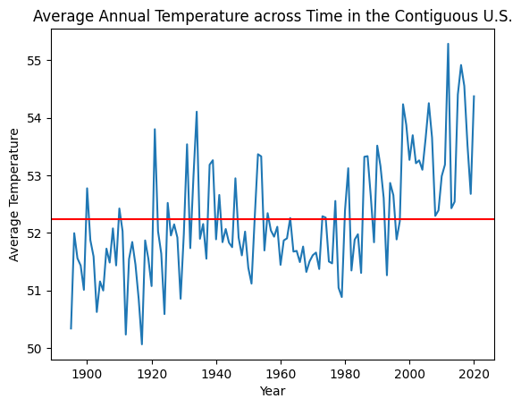

```python
annual_avg = data.groupby(data['Date'].dt.year)['Value'].mean()
data2 = pd.DataFrame()
data2['Date'] = annual_avg.keys()
data2['Temperature'] = annual_avg.values

fig = sns.lineplot(x=data2['Date'], y=data2['Temperature'], data=data2)
plt.title("Average Annual Temperature across Time in the Contiguous U.S.")
plt.xlabel("Year")
plt.ylabel("Average Temperature")
plt.axhline(data2['Temperature'].mean(), color='red')
plt.show()
```

It's clear from the graph here that there has been an increase in average temperatures over the years. This is especially apparent when you observe that in recent years, the temperatures have gone past the red mean line, even at its lowest points.

## Hypothesis Testing

We use hypothesis testing to determine whether or not a hypothesis about a population is true. This is important in data science because it allows us to draw conclusions from our data and make informed decisions based on statistical evidence. For our data, we are going to do a one sample t-test to see if the average temperatures from 1980 onwards are significantly higher than the overall average temperature. In this case, the null hypothesis would be that there is no change in average temperature, while the alternative hypothesis is that there is an increase in average temperature. To get test statistic, we will use the SciPy stats module:

```python
import scipy.stats as stats

t_statistic, p_value = stats.ttest_1samp(a=data2['Temperature'].iloc[85:], popmean=data2['Temperature'].mean())
print("t-statistic:", t_statistic)
print("p-value:", p_value)
```

```
t-statistic: 5.372312120260752
p-value: 3.591811008296598e-06
```

With a p-value of 0.00000359 its safe to say we can reject the null hypothesis.

## Conclusion

It's clear that there is strong evidence that climate change is real. The data we analyzed supports the hypothesis that the average temperature in the contiguous United States is increasing over time. These findings are in line with the overwhelming scientific consensus on the existence of climate change and further highlight the need to address this issue.